# Introduction to linear regression

Alexis Mekueko

11/4/2020

Github link: https://github.com/asmozo24/DATA606_Homework_Presentation

Web linl: https://rpubs.com/amekueko/684788

## R Packages

```r
#loading all library needed for this assignment
library(tidyverse)
library(magick)
```

# Summary

Linear regression is one of the statistical techniques used to determine whether or not an observation has a linear relationship with the observed response. This technique consists of : fitting a line, residuals, and correlation and Least squares regression. Let’s use linear regression to the following problem.

# Problem Statement

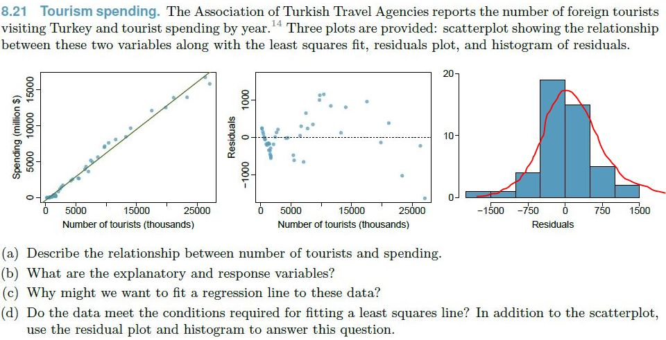

# Answers:

#### (a) Describe the relationship between number of tourists and spending.

Answer:  
As the number of tourists was increasing, their spending in Turkish was going up too. So, there is likely a linear relationship between the number of tourists and their spending by year. y = ax + b

#### (b) What are the explanatory and response variables?

Answer:  
The response variables = tourist spending by year, explanatory = Number of tourists by year

#### (d) Do the data meet the conditions required for fitting a least squares line? In addition to the scatterplot, use the residual plot and histogram to answer this question.

Answer: yes.

##### Nearly normal residuals:

Based on the histogram plot, the data shows a normal distribution unimodal bell-shaped.

##### Independent observations:

Based on the problem statement, the sample is likely independent since the data collected from the number of tourists does not influence the spending. The problem did not let’s think otherwise.